# PracticeMachineLearningAssignment

Disovankiri Boung

8/8/2020

# Practice Machine Learning

Using devices such as Jawbone Up, Nike FuelBand, and Fitbit it is now possible to collect a large amount of data about personal activity relatively inexpensively. These type of devices are part of the quantified self movement – a group of enthusiasts who take measurements about themselves regularly to improve their health, to find patterns in their behavior, or because they are tech geeks. One thing that people regularly do is quantify how much of a particular activity they do, but they rarely quantify how well they do it. In this project, your goal will be to use data from accelerometers on the belt, forearm, arm, and dumbell of 6 participants. They were asked to perform barbell lifts correctly and incorrectly in 5 different ways. More information is available from the website here: http://groupware.les.inf.puc-rio.br/har (see the section on the Weight Lifting Exercise Dataset).

## Data

The data for this project comes from:

Velloso, E.; Bulling, A.; Gellersen, H.; Ugulino, W.; Fuks, H. Qualitative Activity Recognition of Weight Lifting Exercises. Proceedings of 4th International Conference in Cooperation with SIGCHI (Augmented Human ’13) . Stuttgart, Germany: ACM SIGCHI, 2013.

Read more: http://groupware.les.inf.puc-rio.br/har#wle_paper_section#ixzz6UaDAwCTK

The training data for this project are available here: [https://d396qusza40orc.cloudfront.net/predmachlearn/pml-training.csv]

The test data are available here: [https://d396qusza40orc.cloudfront.net/predmachlearn/pml-testing.csv]

## Summary

In this project, we used Machine Learning Technique to predict outcome variable which is classe, a factor variable consist of A,B,C,D,and E. Participants were asked to perform one set of 10 repetitions of the Unilateral Dumbbell Biceps Curl in 5 different fashions:

- exactly according to the specification (Class A)
- throwing the elbows to the front (Class B)
- lifting the dumbbell only halfway (Class C)
- lowering the dumbbell only halfway (Class D)
- throwing the hips to the front (Class E)

We use the following steps to do our analysis:

- To reproduce the result again, we set seed to be 497
- We split the training data into subtraning (70%), and subtesting (30%)
- We used the subtraining data to build 2 models ,namely, Decision Tree and RandomForest
- We cross-validate the model with the subtesting data before used it with the real testing data
- According to the subtesting dataset, RandomForest has higher accuracy rate than Decision Tree model

```r
library(lattice); library(ggplot2); library(caret); library(randomForest); library(rpart); library(rpart.plot); library(rattle)
```

### Importing Dataset

```r
set.seed(497)
training <- read.csv("pml-training.csv", na.strings=c("NA","#DIV/0!", ""))
test <- read.csv("pml-testing.csv", na.strings=c("NA","#DIV/0!", ""))

dim(training); dim(test)
```

```
[1] 19622   160
```

```
[1]  20 160
```

```r
# drop column with all NA value
training <- training[,colSums(is.na(training)) == 0]
test <- test[,colSums(is.na(test)) == 0]
```

### Cross-Validation

In order to cross-validate our best fitted model, we split our training set into training (70% of training dataset) and testing (30% of training dataset).

### Out-of-sample error

The expected out-of-sample error will correspond to the quantity: 1-accuracy in the cross-validation data. Accuracy is the proportion of correct classified observation over the total sample in the subTesting data set. Thus, the expected value of the out-of-sample error will correspond to the expected number of missclassified observations/total observations in the Test data set, which is the quantity: 1-accuracy found from the cross-validation data set.

### Reasons for my models

I chose RandomForest as my model because it has the highest Accuracy (meaning lowest out-of-sample error)

```r
#Split training dataset into Training Subsample, and Testing Subsample
subsample <- createDataPartition(y=training$classe,p=0.70,list=FALSE)
TrainingSub <- training[subsample,]
TestSub <- training[-subsample,]

#Removing the frist 7 columns which are not neccessary
TrainingSub <- TrainingSub[,-c(1:7)]
TestSub <- TestSub[,-c(1:7)]

dim(TrainingSub)
```

```
[1] 13737    53
```

```r
dim(TestSub)
```

```
[1] 5885   53
```

### Prediction 1: Decision Tree

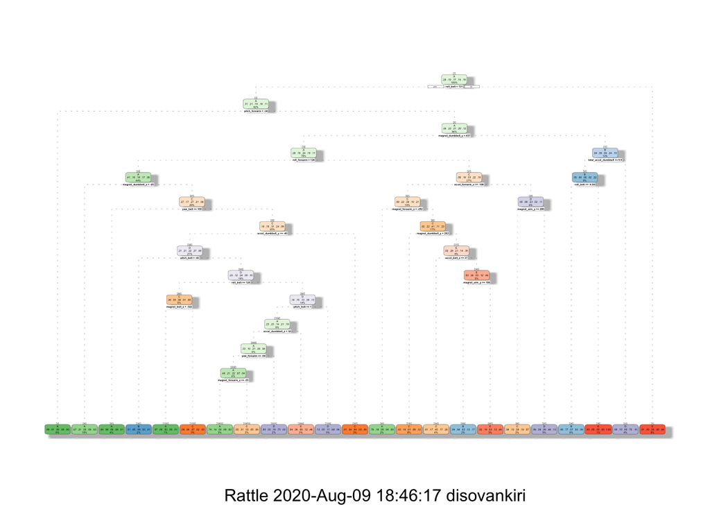

```r
#building model
model1 <- rpart(classe~.,data=TrainingSub,method="class")

#prediction
predict1 <- predict(model1,TestSub,type="class")

#plot
fancyRpartPlot(model1)
```

```r
confusionMatrix(predict1,TestSub$classe)
```

```
Confusion Matrix and Statistics

          Reference
Prediction    A    B    C    D    E
         A 1515  254   21  111   36
         B   36  534   61   25   71
         C   47  188  872  113  129
         D   66   68   67  650   67
         E   10   95    5   65  779

Overall Statistics

               Accuracy : 0.7392
                 95% CI : (0.7277, 0.7503)
    No Information Rate : 0.2845
    P-Value [Acc > NIR] : < 2.2e-16

                  Kappa : 0.6686

 Mcnemar's Test P-Value : < 2.2e-16

Statistics by Class:

                     Class: A Class: B Class: C Class: D Class: E
Sensitivity            0.9050  0.46883   0.8499   0.6743   0.7200
Specificity            0.8998  0.95933   0.9018   0.9455   0.9636
Pos Pred Value         0.7821  0.73453   0.6464   0.7081   0.8166
Neg Pred Value         0.9597  0.88271   0.9660   0.9368   0.9386
Prevalence             0.2845  0.19354   0.1743   0.1638   0.1839
Detection Rate         0.2574  0.09074   0.1482   0.1105   0.1324
Detection Prevalence   0.3291  0.12353   0.2292   0.1560   0.1621
Balanced Accuracy      0.9024  0.71408   0.8759   0.8099   0.8418
```

### Second Prediction: Random Forest

```r
model2 <- randomForest(classe ~. , data=TrainingSub, method="class")

predict2 <- predict(model2, TestSub, type = "class")

confusionMatrix(predict2,TestSub$classe)
```

```
Confusion Matrix and Statistics

          Reference
Prediction    A    B    C    D    E
         A 1674    4    0    0    0
         B    0 1128    9    0    0
         C    0    7 1016   12    0
         D    0    0    1  948    4
         E    0    0    0    4 1078

Overall Statistics

               Accuracy : 0.993
                 95% CI : (0.9906, 0.995)
    No Information Rate : 0.2845
    P-Value [Acc > NIR] : < 2.2e-16

                  Kappa : 0.9912

 Mcnemar's Test P-Value : NA

Statistics by Class:

                     Class: A Class: B Class: C Class: D Class: E
Sensitivity            1.0000   0.9903   0.9903   0.9834   0.9963
Specificity            0.9991   0.9981   0.9961   0.9990   0.9992
Pos Pred Value         0.9976   0.9921   0.9816   0.9948   0.9963
Neg Pred Value         1.0000   0.9977   0.9979   0.9968   0.9992
Prevalence             0.2845   0.1935   0.1743   0.1638   0.1839
Detection Rate         0.2845   0.1917   0.1726   0.1611   0.1832
Detection Prevalence   0.2851   0.1932   0.1759   0.1619   0.1839
Balanced Accuracy      0.9995   0.9942   0.9932   0.9912   0.9977
```

### Applying RandomForest (Model2) to our Test Dataset

```r
predict_final <- predict(model2, test, type="class")

predict_final
```

```
 1  2  3  4  5  6  7  8  9 10 11 12 13 14 15 16 17 18 19 20
 B  A  B  A  A  E  D  B  A  A  B  C  B  A  E  E  A  B  B  B
Levels: A B C D E
```